# R Notebook

```r
library(lme4)
library(MAST)
library(data.table)
library(R.utils)
library(doParallel)
library(stringr)
```

# Processing data

```r
fnm1 = "GSE120575_Sade_Feldman_melanoma_single_cells_nolabel_1.txt.gz"
fnm2 = "GSE120575_Sade_Feldman_melanoma_single_cells_2.txt.gz"

sf_tpm1 = fread(paste0("../../scRNAseq/Sade_Feldman_2018/", fnm1),
                fill = TRUE, header = TRUE)

sf_tpm2 = fread(paste0("../../scRNAseq/Sade_Feldman_2018/", fnm2),
                fill = TRUE, drop = 16293, col.names = colnames(sf_tpm1))

ls_tpm = list(sf_tpm1,sf_tpm2)
rm(sf_tpm1)
rm(sf_tpm2)

sf_tpm = rbindlist(ls_tpm)

rm(ls_tpm)
```

```r
dim(sf_tpm) # 55737 x 16292
```

```
## [1] 55737 16292
```

```r
sf_tpm[1:2,1:4]
```

| V1 | A10_P3_M11 | A11_P1_M11 | A11_P3_M11 |
| --- | --- | --- | --- |
| TSPAN6 | 0 | 0 | 0 |
| TNMD | 0 | 0 | 0 |

```r
gene.names = sf_tpm$V1
rownames(sf_tpm) = gene.names
sf_tpm$V1 = NULL
```

Only select classified cells

```r
cell_type = read.table("./output/cell_type.txt", header = TRUE,
                       sep = "\t", as.is = TRUE)
dim(cell_type)
```

```
## [1] 16291     4
```

```r
cell_type[1:2,]
```

|  | cell | type1 | type2 | type |
| --- | --- | --- | --- | --- |
| 1 | A10_P3_M11 | unclustered | NK2 | NK2 |
| 2 | A11_P1_M11 | unclustered | NK2 | NK2 |

```r
table(cell_type$type, useNA="ifany")
```

```
##
##               B_cells           CD4T_memory                CD8T_B
##                  1421                  1099                  2458
##                CD8T_G       Dendritic_cells Monocytes_Macrophages
##                  3033                   275                  1341
##                   NK1                   NK2                   NK3
##                   463                  1904                  1146
##          Plasma_cells                 Tregs           unclustered
##                   290                  1313                  1548
```

```r
clustered_cells = cell_type$cell[cell_type$type != "unclustered"]
cluster_sf_tpm  = sf_tpm[, ..clustered_cells]
dim(cluster_sf_tpm)
```

```
## [1] 55737 14743
```

```r
rownames(cluster_sf_tpm) = gene.names
cluster_sf_tpm[1:3,1:3]
```

| A10_P3_M11 | A11_P1_M11 | A11_P3_M11 |
| --- | --- | --- |
| 0 | 0.00 | 0 |
| 0 | 0.00 | 0 |
| 0 | 9.24 | 0 |

```r
rm(sf_tpm)
rm(clustered_cells)
```

# Select ~10,000 genes expressed in at least a proportion of cells

Calculate the proportion of cells that each gene is expressed in

```r
cells.per.gene    = rowSums(cluster_sf_tpm > 0)
cellprop.per.gene = cells.per.gene/ncol(cluster_sf_tpm)
summary(cellprop.per.gene)
```

```
##      Min.   1st Qu.    Median      Mean   3rd Qu.      Max.
## 0.0000000 0.0002713 0.0018314 0.0436938 0.0233331 1.0000000
```

```r
table(cellprop.per.gene > 0.02)
```

```
##
## FALSE  TRUE
## 41155 14582
```

```r
table(cellprop.per.gene > 0.03)
```

```
##
## FALSE  TRUE
## 42873 12864
```

```r
table(cellprop.per.gene > 0.04)
```

```
##
## FALSE  TRUE
## 44144 11593
```

```r
table(cellprop.per.gene > 0.05)
```

```
##
## FALSE  TRUE
## 45096 10641
```

```r
he.genes = gene.names[cellprop.per.gene > 0.05]
HEgenes_cluster_tpm = cluster_sf_tpm[cellprop.per.gene > 0.05, ]
rownames(HEgenes_cluster_tpm) = he.genes
dim(HEgenes_cluster_tpm)
```

```
## [1] 10641 14743
```

```r
summary(cellprop.per.gene[cellprop.per.gene > 0.05])
```

```
##    Min. 1st Qu.  Median    Mean 3rd Qu.    Max.
## 0.05006 0.08757 0.14726 0.20696 0.25883 1.00000
```

```r
rm(cellprop.per.gene)
rm(cells.per.gene)
rm(cluster_sf_tpm)
```

# Average expression of each gene in each cell type

First calculate the expression of each gene across all cells

```r
all.expression = rowSums(HEgenes_cluster_tpm)
```

u_CT1: average expression of each gene in cell type CT1. o_CT1: average expression of each gene in all the cells that do not belong to cell type CT1.

```r
average_expression = data.frame(gene = he.genes)
levels(factor(cell_type$type))
```

```
##  [1] "B_cells"               "CD4T_memory"           "CD8T_B"
##  [4] "CD8T_G"                "Dendritic_cells"       "Monocytes_Macrophages"
##  [7] "NK1"                   "NK2"                   "NK3"
## [10] "Plasma_cells"          "Tregs"                 "unclustered"
```

```r
for (i in levels(factor(cell_type$type))[-12]) {
  # select cells in each cell cluster
  cc = cell_type$cell[cell_type$type == i]
  # total expression of each gene across all the cells of a particular cluster
  cluster.exp = apply(HEgenes_cluster_tpm[, ..cc], 1, sum)
  # total expression of each gene across all other cells
  exclu.exp = all.expression - cluster.exp
  # divide by the number of cells in the cluster to get the average expression
  aveg.cluster.exp = cluster.exp / length(cc)
  # divide by the number of all other cells to get the average expression
  aveg.exclu.exp = exclu.exp / (ncol(HEgenes_cluster_tpm) - length(cc))

  fc = aveg.exclu.exp / aveg.cluster.exp

  ulabel = paste0("u_",i)
  average_expression[[ulabel]] = aveg.cluster.exp

  olabel = paste0("o_",i)
  average_expression[[olabel]] = aveg.exclu.exp

  fclabel = paste0("fc_",i)
  average_expression[[fclabel]] = fc
}

rm(cc)
rm(cluster.exp)
rm(exclu.exp)
rm(aveg.cluster.exp)
rm(aveg.exclu.exp)
rm(fc)
for(i in 1:5){ gc() }
gc()
```

```
##             used   (Mb) gc trigger   (Mb) limit (Mb)   max used    (Mb)
## Ncells   5811484  310.4    8942014  477.6         NA    8133595   434.4
## Vcells 258069625 1969.0  714846216 5453.9      32768 2726921859 20804.8
```

```r
write.table(average_expression, quote = FALSE,
            file = "output/Average_GeneExpression_by_CellType.txt",
            sep = "\t", row.names = FALSE, col.names = TRUE)
```

# Testing differential gene expression

## Loading sample/patient information

```r
dir = "../../scRNAseq/Sade_Feldman_2018/"
fnm = paste0(dir, "GSE120575_patient_ID_single_cells_rm_headers.txt")

info.SF = fread(fnm)
dim(info.SF)
```

```
## [1] 16291    35
```

```r
info.SF[1:2,]
```

| Sample name | title | source name | organism | characteristics: patinet ID (Pre=baseline; Post= on treatment) | characteristics: response | characteristics: therapy | molecule | description | processed data file | raw file | V12 | V13 | V14 | V15 | V16 | V17 | V18 | V19 | V20 | V21 | V22 | V23 | V24 | V25 | V26 | V27 | V28 | V29 | V30 | … |
| --- | --- | --- | --- | --- | --- | --- | --- | --- | --- | --- | --- | --- | --- | --- | --- | --- | --- | --- | --- | --- | --- | --- | --- | --- | --- | --- | --- | --- | --- | --- |
| Sample 1 | A10_P3_M11 | Melanoma single cell | Homo sapiens | Pre_P1 | Responder | anti-CTLA4 | NA | NA | NA | NA | NA | NA | NA | NA | NA | NA | NA | NA | NA | NA | NA | NA | NA | NA | NA | NA | NA | NA | NA | … |
| Sample 2 | A11_P1_M11 | Melanoma single cell | Homo sapiens | Pre_P1 | Responder | anti-CTLA4 | NA | NA | NA | NA | NA | NA | NA | NA | NA | NA | NA | NA | NA | NA | NA | NA | NA | NA | NA | NA | NA | NA | NA | … |

```r
names(info.SF) = gsub("characteristics: ", "", names(info.SF))
names(info.SF)[5] = "sampleID"

all(is.na(c(data.matrix(info.SF[,8:35]))))
```

```
## [1] TRUE
```

```r
info.SF = info.SF[,1:7]

pIDs = str_split_fixed(info.SF$sampleID, "_", 2)
dim(pIDs)
```

```
## [1] 16291     2
```

```r
pIDs[1:2,]
```

```
##      [,1]  [,2]
## [1,] "Pre" "P1"
## [2,] "Pre" "P1"
```

```r
info.SF$patientID = pIDs[,2]
info.SF$type = pIDs[,1]

dim(info.SF)
```

```
## [1] 16291     9
```

```r
info.SF[1:2,]
```

| Sample name | title | source name | organism | sampleID | response | therapy | patientID | type |
| --- | --- | --- | --- | --- | --- | --- | --- | --- |
| Sample 1 | A10_P3_M11 | Melanoma single cell | Homo sapiens | Pre_P1 | Responder | anti-CTLA4 | P1 | Pre |
| Sample 2 | A11_P1_M11 | Melanoma single cell | Homo sapiens | Pre_P1 | Responder | anti-CTLA4 | P1 | Pre |

```r
length(unique(info.SF$title))
```

```
## [1] 16291
```

```r
length(unique(info.SF$patientID))
```

```
## [1] 37
```

```r
info.SF.ind = unique(info.SF[,.(patientID, sampleID, type, response, therapy)])
dim(info.SF.ind)
```

```
## [1] 48  5
```

```r
info.SF.ind[1:2,]
```

| patientID | sampleID | type | response | therapy |
| --- | --- | --- | --- | --- |
| P1 | Pre_P1 | Pre | Responder | anti-CTLA4 |
| P1 | Post_P1 | Post | Responder | anti-PD1 |

```r
table(info.SF.ind$response, info.SF.ind$therapy)
```

```
##
##                 anti-CTLA4 anti-CTLA4+PD1 anti-PD1
##   Non-responder          1              4       26
##   Responder              1              7        9
```

```r
table(info.SF.ind$response, info.SF.ind$type)
```

```
##
##                 Post Pre
##   Non-responder   21  10
##   Responder        8   9
```

```r
sort(table(info.SF$sampleID))
```

```
##
##    Pre_P29   Post_P21     Pre_P1    Post_P7    Pre_P35     Pre_P3   Post_P22
##        163        213        229        231        238        245        260
##     Pre_P8   Post_P17     Pre_P6    Post_P1    Post_P5   Post_P15    Pre_P15
##        267        281        288        291        292        304        304
##     Pre_P4   Post_P11   Post_P12    Pre_P20   Post_P14    Pre_P12    Pre_P26
##        311        313        323        323        329        330        333
##  Post_P5_2     Pre_P2    Pre_P28    Pre_P24    Pre_P27    Pre_P31  Post_P1_2
##        336        337        337        338        343        351        353
##   Post_P18   Post_P20   Post_P23  Post_P3_2    Post_P3 Post_P23_2     Pre_P7
##        357        358        358        358        359        362        368
##   Post_P28   Post_P30    Pre_P25 Post_P28_2    Post_P2   Post_P10    Post_P6
##        369        369        371        372        380        396        400
##   Post_P19    Post_P8   Post_P13    Pre_P33   Post_P16    Post_P4
##        403        409        449        452        463        675
```

```r
table(tapply(info.SF.ind$type, info.SF.ind$patientID, paste, collapse=":"))
```

```
##
##     Post      Pre Pre:Post
##       18        8       11
```

## Prepare gene expression data

The tutorial for MAST mentioned that the data should be a matrix of log2 + 1 transcripts per million (TPM). The data from Sade-Feldman et al. (2018) are in TPM format, so I transfromed it with log2(x+1):

```r
table(names(HEgenes_cluster_tpm) %in% info.SF$title)
```

```
##
##  TRUE
## 14743
```

```r
info.SF_HEgenes = info.SF[match(names(HEgenes_cluster_tpm), info.SF$title),]
dim(info.SF_HEgenes)
```

```
## [1] 14743     9
```

```r
info.SF_HEgenes[1:2,]
```

| Sample name | title | source name | organism | sampleID | response | therapy | patientID | type |
| --- | --- | --- | --- | --- | --- | --- | --- | --- |
| Sample 1 | A10_P3_M11 | Melanoma single cell | Homo sapiens | Pre_P1 | Responder | anti-CTLA4 | P1 | Pre |
| Sample 2 | A11_P1_M11 | Melanoma single cell | Homo sapiens | Pre_P1 | Responder | anti-CTLA4 | P1 | Pre |

```r
sort(table(info.SF_HEgenes$patientID))
```

```
##
##   P29   P21   P35   P22   P11    P5   P17   P14  P5_2   P31   P27   P24 P23_2
##   156   203   214   222   235   259   273   286   309   310   312   316   317
##   P26   P18  P1_2   P30   P10   P23   P25 P28_2  P3_2   P19   P33   P13   P16
##   320   326   329   330   332   337   340   344   351   390   399   408   429
##    P1    P7   P15   P12    P3    P8   P20    P2   P28    P6    P4
##   452   525   543   567   569   630   635   644   657   667   807
```

```r
HEgenes_cluster_tpm_log = log2(1 + as.matrix(HEgenes_cluster_tpm))

row.names(HEgenes_cluster_tpm_log) = he.genes
cell.id = colnames(HEgenes_cluster_tpm_log)

dim(HEgenes_cluster_tpm_log)
```

```
## [1] 10641 14743
```

```r
HEgenes_cluster_tpm_log[1:2,1:5]
```

```
##       A10_P3_M11 A11_P1_M11 A11_P3_M11 A11_P4_M11 A12_P3_M11
## DPM1           0   3.356144          0   3.168321          0
## SCYL3          0   0.000000          0   0.000000          0
```

## Calculating the CDR rate: proportion of genes detected for each cell

```r
cdr = colMeans(HEgenes_cluster_tpm > 0)
summary(cdr)
```

```
##    Min. 1st Qu.  Median    Mean 3rd Qu.    Max.
## 0.08448 0.15356 0.18523 0.20696 0.23447 0.67569
```

## Preparing a SingleCellAssay object for MAST

```r
fData = data.frame(primerid = he.genes)
cData = data.frame(wellKey = cell.id)

sca = FromMatrix(HEgenes_cluster_tpm_log, cData, fData)
```

```
## Assuming data assay in position 1, with name et is log-transformed.
```

```r
colData(sca)$cngeneson = scale(cdr)
colData(sca)$patientID = info.SF_HEgenes$patientID

uniq_cell_types = sort(unique(cell_type$type))

for(i in 1:11){
  label = uniq_cell_types[i]
  colData(sca)[[label]] = "control"
  caseid = match(cell_type$cell[cell_type$type == label],colData(sca)$wellKey)
  colData(sca)[[label]][caseid] = "case"
  colData(sca)[[label]] = as.factor(colData(sca)[[label]])
}

colData(sca)
```

```
## DataFrame with 14743 rows and 14 columns
##                                             wellKey          cngeneson
##                                         <character>           <matrix>
## A10_P3_M11                               A10_P3_M11 -0.425092173776452
## A11_P1_M11                               A11_P1_M11 -0.839262909803626
## A11_P3_M11                               A11_P3_M11  -0.83690966698529
## A11_P4_M11                               A11_P4_M11  0.587978859517289
## A12_P3_M11                               A12_P3_M11  -1.27343620978666
## ...                                             ...                ...
## H5_P5_M67_L001_T_enriched H5_P5_M67_L001_T_enriched   2.04345954265824
## H6_P5_M67_L001_T_enriched H6_P5_M67_L001_T_enriched   2.62941700442396
## H7_P5_M67_L001_T_enriched H7_P5_M67_L001_T_enriched  0.888017318855156
## H8_P5_M67_L001_T_enriched H8_P5_M67_L001_T_enriched  -1.13106501927732
## H9_P5_M67_L001_T_enriched H9_P5_M67_L001_T_enriched -0.813377238801928
##                             patientID  B_cells CD4T_memory   CD8T_B   CD8T_G
##                           <character> <factor>    <factor> <factor> <factor>
## A10_P3_M11                         P1  control     control  control  control
## A11_P1_M11                         P1  control     control  control  control
## A11_P3_M11                         P1  control     control  control  control
## A11_P4_M11                         P1  control     control  control  control
## A12_P3_M11                         P1  control     control  control  control
## ...                               ...      ...         ...      ...      ...
## H5_P5_M67_L001_T_enriched          P6  control     control  control  control
## H6_P5_M67_L001_T_enriched          P6  control     control  control  control
## H7_P5_M67_L001_T_enriched          P6  control     control  control  control
## H8_P5_M67_L001_T_enriched          P6  control     control  control  control
## H9_P5_M67_L001_T_enriched          P6  control     control  control  control
##                           Dendritic_cells Monocytes_Macrophages      NK1
##                                  <factor>              <factor> <factor>
## A10_P3_M11                        control               control  control
## A11_P1_M11                        control               control  control
## A11_P3_M11                        control               control  control
## A11_P4_M11                        control               control  control
## A12_P3_M11                        control               control  control
## ...                                   ...                   ...      ...
## H5_P5_M67_L001_T_enriched         control               control     case
## H6_P5_M67_L001_T_enriched         control               control     case
## H7_P5_M67_L001_T_enriched         control               control  control
## H8_P5_M67_L001_T_enriched         control               control  control
## H9_P5_M67_L001_T_enriched         control               control  control
##                                NK2      NK3 Plasma_cells    Tregs
##                           <factor> <factor>     <factor> <factor>
## A10_P3_M11                    case  control      control  control
## A11_P1_M11                    case  control      control  control
## A11_P3_M11                    case  control      control  control
## A11_P4_M11                 control  control      control     case
## A12_P3_M11                    case  control      control  control
## ...                            ...      ...          ...      ...
## H5_P5_M67_L001_T_enriched  control  control      control  control
## H6_P5_M67_L001_T_enriched  control  control      control  control
## H7_P5_M67_L001_T_enriched  control     case      control  control
## H8_P5_M67_L001_T_enriched     case  control      control  control
## H9_P5_M67_L001_T_enriched     case  control      control  control
```

```r
rm(HEgenes_cluster_tpm)
rm(HEgenes_cluster_tpm_log)
for(i in 1:5){ gc() }
gc()
```

```
##             used   (Mb) gc trigger   (Mb) limit (Mb)   max used    (Mb)
## Ncells   5845735  312.2    8942014  477.6         NA    8263390   441.4
## Vcells 258768629 1974.3  742180547 5662.4      32768 2726921859 20804.8
```

## Fitting model, for one cell type to compare standard model vs. mixed effect model

```r
# number of cores for multi-core computation
nCore = 5
registerDoParallel(cores=nCore)
options(mc.cores=nCore)
getOption("mc.cores")
```

```
## [1] 5
```

```r
i = 1
cti = uniq_cell_types[i]
f0  = as.formula(sprintf("~ %s + cngeneson", cti))
f1  = as.formula(sprintf("~ %s + cngeneson + (1|patientID)", cti))

date()
```

```
## [1] "Thu Nov 26 14:49:51 2020"
```

```r
b0  = zlm(formula = f0, sca = sca, parallel = TRUE)
```

```
##
## Done!
```

```r
date()
```

```
## [1] "Thu Nov 26 14:53:13 2020"
```

```r
b1 = zlm(formula = f1, sca=sca, method = "glmer", ebayes=F, parallel = T)
```

```
##
## Done!
```

```r
date()
```

```
## [1] "Thu Nov 26 15:44:42 2020"
```

```r
lrt0 = lrTest(b0, cti)
```

```
## Refitting on reduced model...
##
## Done!
```

```r
date()
```

```
## [1] "Thu Nov 26 15:50:27 2020"
```

```r
lrt1 = lrTest(b1, cti)
```

```
## Refitting on reduced model...
##
## Done!
```

```r
date()
```

```
## [1] "Thu Nov 26 16:25:57 2020"
```

```r
mast_pval_zlm  = apply(lrt0, 1, function(x){x[3,3]})
mas_pval_zlmer = apply(lrt1, 1, function(x){x[3,3]})

summary(mast_pval_zlm)
```

```
##     Min.  1st Qu.   Median     Mean  3rd Qu.     Max.
## 0.000000 0.000000 0.001818 0.135111 0.149785 0.999647
```

```r
summary(mas_pval_zlmer)
```

```
##      Min.   1st Qu.    Median      Mean   3rd Qu.      Max.      NA's
## 0.0000000 0.0000001 0.0090784 0.1598833 0.2222523 1.0000000         1
```

```r
min(mast_pval_zlm)
```

```
## [1] 0
```

```r
min(mast_pval_zlm[mast_pval_zlm > 0])
```

```
## [1] 1.770237e-320
```

```r
table(mast_pval_zlm < 1e-100)
```

```
##
## FALSE  TRUE
## 10229   412
```

```r
table(mas_pval_zlmer < 1e-100)
```

```
##
## FALSE  TRUE
## 10341   299
```

```r
mast_pval_zlm[which(mast_pval_zlm < 1e-100)] = 1e-100
mas_pval_zlmer[which(mas_pval_zlmer < 1e-100)] = 1e-100

cor(-log10(mast_pval_zlm), -log10(mas_pval_zlmer), use="pairwise")
```

```
## [1] 0.9710617
```

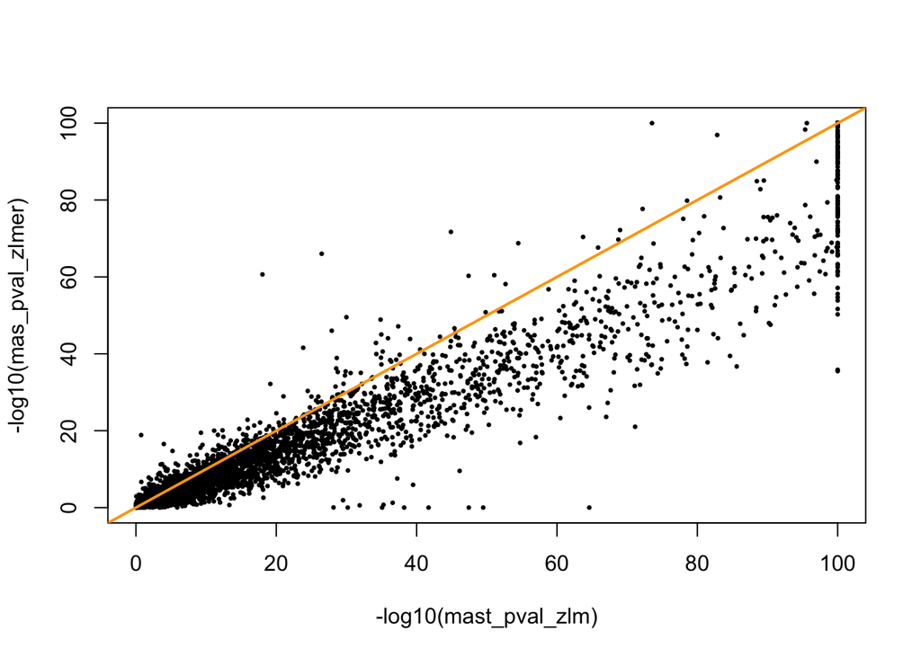

```r
plot(-log10(mast_pval_zlm), -log10(mas_pval_zlmer), pch=20, cex=0.5)
abline(0, 1, col="orange", lwd=2)
```

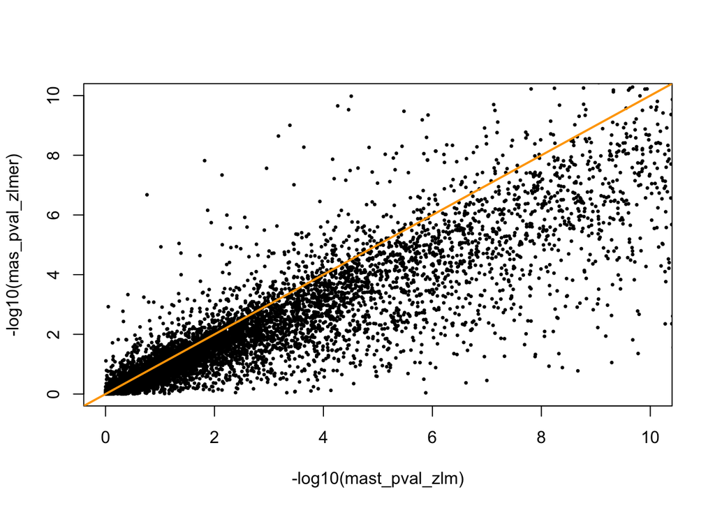

```r
plot(-log10(mast_pval_zlm), -log10(mas_pval_zlmer), xlim=c(0,10), ylim=c(0,10), pch=20, cex=0.5)
abline(0, 1, col="orange", lwd=2)
```

## Fitting model, for all other cell types

```r
# number of cores for multi-core computation
nCore = 5
registerDoParallel(cores=nCore)
options(mc.cores=nCore)
getOption("mc.cores")
```

```
## [1] 5
```

```r
mast_pval_zlm_df = fData
names(mast_pval_zlm_df)[1] = "gene"

for(i in 1:11){
  cti = uniq_cell_types[i]

  cat(i, cti, date(), "\n")
  f0  = as.formula(sprintf("~ %s + cngeneson", cti))
  b0  = zlm(formula = f0, sca = sca, parallel = TRUE)
  cat("start lrtest", date(), "\n")

  lrt0 = lrTest(b0, cti)

  mast_pval_zlm_df[[cti]]  = apply(lrt0, 1, function(x){x[3,3]})
  gc()
}
```

```
## 1 B_cells Thu Nov 26 16:25:59 2020
```

```
##
## Done!
```

```
## start lrtest Thu Nov 26 16:31:34 2020
```

```
## Refitting on reduced model...
##
## Done!
```

```
## 2 CD4T_memory Thu Nov 26 16:37:50 2020
```

```
##
## Done!
```

```
## start lrtest Thu Nov 26 16:42:44 2020
```

```
## Refitting on reduced model...
##
## Done!
```

```
## 3 CD8T_B Thu Nov 26 16:46:44 2020
```

```
##
## Done!
```

```
## start lrtest Thu Nov 26 16:49:17 2020
```

```
## Refitting on reduced model...
##
## Done!
```

```
## 4 CD8T_G Thu Nov 26 16:52:38 2020
```

```
##
## Done!
```

```
## start lrtest Thu Nov 26 16:55:38 2020
```

```
## Refitting on reduced model...
##
## Done!
```

```
## 5 Dendritic_cells Thu Nov 26 16:58:27 2020
```

```
##
## Done!
```

```
## start lrtest Thu Nov 26 17:01:35 2020
```

```
## Refitting on reduced model...
##
## Done!
```

```
## 6 Monocytes_Macrophages Thu Nov 26 17:04:11 2020
```

```
##
## Done!
```

```
## start lrtest Thu Nov 26 17:07:37 2020
```

```
## Refitting on reduced model...
##
## Done!
```

```
## 7 NK1 Thu Nov 26 17:11:00 2020
```

```
##
## Done!
```

```
## start lrtest Thu Nov 26 17:14:43 2020
```

```
## Refitting on reduced model...
##
## Done!
```

```
## 8 NK2 Thu Nov 26 17:18:54 2020
```

```
##
## Done!
```

```
## start lrtest Thu Nov 26 17:22:15 2020
```

```
## Refitting on reduced model...
##
## Done!
```

```
## 9 NK3 Thu Nov 26 17:24:35 2020
```

```
##
## Done!
```

```
## start lrtest Thu Nov 26 17:28:03 2020
```

```
## Refitting on reduced model...
##
## Done!
```

```
## 10 Plasma_cells Thu Nov 26 17:31:32 2020
```

```
##
## Done!
```

```
## start lrtest Thu Nov 26 17:35:27 2020
```

```
## Refitting on reduced model...
##
## Done!
```

```
## 11 Tregs Thu Nov 26 17:38:57 2020
```

```
##
## Done!
```

```
## start lrtest Thu Nov 26 17:45:18 2020
```

```
## Refitting on reduced model...
##
## Done!
```

```r
dim(mast_pval_zlm_df)
```

```
## [1] 10641    12
```

```r
mast_pval_zlm_df[1:2,]
```

|  | gene | B_cells | CD4T_memory | CD8T_B | CD8T_G | Dendritic_cells | Monocytes_Macrophages | NK1 | NK2 | NK3 | Plasma_cells | Tregs |
| --- | --- | --- | --- | --- | --- | --- | --- | --- | --- | --- | --- | --- |
| 1 | DPM1 | 0.2553168 | 0.07700829 | 0.003119275 | 0.51220500 | 0.4994158 | 1.134884e-01 | 7.732547e-01 | 0.008663793 | 0.4104896 | 1.272213e-37 | 0.02695183 |
| 2 | SCYL3 | 0.5454825 | 0.01568455 | 0.013280471 | 0.03779512 | 0.1499796 | 1.158338e-11 | 4.222862e-05 | 0.170002350 | 0.2924719 | 5.796100e-06 | 0.65058476 |

```r
write.csv(mast_pval_zlm_df, file = "output/MastGenePvals_by_CellType.csv",
          quote = FALSE)
```

```r
gc()
```

```
##             used   (Mb) gc trigger   (Mb) limit (Mb)   max used    (Mb)
## Ncells   5999604  320.5   11630125  621.2         NA   11630125   621.2
## Vcells 262142070 2000.0  872381049 6655.8      32768 2726921859 20804.8
```